# Neural Network Project - DDPM

**DIA 5**

- Lorrain MORLET
- Noemie MAZEPA
- Auriane MARCELINO
- Aymeric MARTIN

The goal of this project is to implement a Denoising Diffusion Probabilistic Model (DDPM) for image generation.

The DDPM is a generative model that learns to generate images by reversing a diffusion process. The model is trained to denoise images that have been corrupted by Gaussian noise, and it learns to generate new images by sampling from the learned distribution.

When we started this project our goal was to make it as scalable as possible. We made each class/ function to make sure that it can be used in different projects as anyone prefers. We also made sure that the code is well documented and easy to understand.

The model will be trained on two different datasets : MNIST first, and then CIFAR-10. The implementation will be done using PyTorch and will include the following components:

- A UNet architecture for the denoising process.
- A Cosine Gaussian noise schedule for the diffusion process.
- A training loop to optimize the model parameters.
- A sampling process to generate new images from the trained model.
- A visualization of the generated images.

## Import Libraries

```python
import torch
import torchvision
import torchvision.transforms as transforms
import torch.nn as nn
from torch.utils.data import DataLoader


import matplotlib.pyplot as plt
import numpy as np

from tqdm import tqdm
```

Let's create a function to display an image easily. It will take a tensor and display it using matplotlib.

```python
def show_image(img:torch.Tensor, title:str=None):
    npimg = img.cpu().detach().numpy()
    npimg = npimg / 2 + 0.5     # unnormalize
    plt.imshow(np.transpose(npimg, (1, 2, 0)), cmap='gray')
    if title is not None:
        plt.title(title)
    plt.show()
```

## Datasets

This class is used to load either the MNIST or CIFAR 10 dataset. It uses the torchvision library to download and transform the dataset. The dataset is split into training and testing sets, and the images are normalized to have a mean of 0.5 and a standard deviation of 0.5. The images are also resized to 32x32 pixels.

### MNIST

The MNIST dataset is a very famous dataset, it's a collection of handwritten digits, consisting of 60,000 training images and 10,000 testing images. Each image is a grayscale image of size 28x28 pixels. The dataset is commonly used for training image processing systems and is a standard benchmark in the field of machine learning.

[figure not shown]

### CIFAR-10

The CIFAR-10 dataset is a collection of 60,000 32x32 color images in 10 classes, with 6,000 images per class. The dataset is divided into 50,000 training images and 10,000 testing images. The classes are: airplane, automobile, bird, cat, deer, dog, frog, horse, ship, and truck. The CIFAR-10 dataset is also a very famous dataset. It's a little bit more complex than MNIST, as it contains color images and multiple classes.

[figure not shown]

```
60000
```

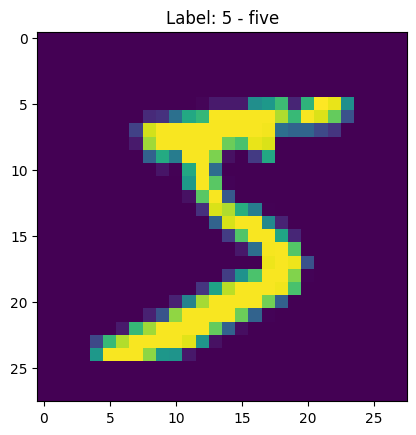

```python
class Dataset():
    def __init__(self, name, split='train', transform=None):
        datasets = {
            'CIFAR10': torchvision.datasets.CIFAR10,
            'MNIST': torchvision.datasets.MNIST,
        }
        if name not in datasets:
            raise ValueError(f"Unknown dataset {name}. Known datasets are {datasets.keys()}")
        if transform is None:
            raise ValueError("Transform should be provided")
        if split not in ['train', 'test']:
            raise ValueError("Split should be either 'train' or 'test'")

        self.split = split
        self.name = name
        self.transform = transform
        self.dataset = datasets[name](root='./data', train = (self.split=='train'),
                                      download=True, transform=self.transform)
        self.classes = self.dataset.classes if hasattr(self.dataset, 'classes') else None

    def show_image(self, idx):
        img, label = self[idx]
        img = img / 2 + 0.5     # unnormalize
        npimg = img.numpy()
        plt.imshow(np.transpose(npimg, (1, 2, 0)))
        plt.title(f"Label: {self.classes[label] if self.classes else label}")
        plt.show()

    def __getitem__(self, idx:int) -> torch.Tensor:
        """Returns a tuple of (image, label)"""
        return self.dataset[idx]

    def __len__(self) -> int:
        return len(self.dataset)

    def __str__(self) -> str:
        return f"Dataset of size {len(self)}"
    def __repr__(self) -> str:
        return str(self)



transform_MNIST = transforms.Compose([
    transforms.ToTensor(),
    transforms.Normalize((0.5, ), (0.5, )),
])
MNIST = Dataset('MNIST', split='train', transform=transform_MNIST)
print(len(MNIST))
MNIST.show_image(0)
```

## Cosine Noise Schedule

```python
class CosineNoiseAdder():
    def __init__(self, T:int=2000, s=0.008):
        self.T = torch.tensor(T)
        self.s = torch.tensor(s) # The value of s is selected such that sqrt(B_0) is slightly smaller than the pixel bin size 1/127.5, which gives s = 0.008.
        self.f = lambda x: torch.cos(((x/self.T) + self.s)/(1+self.s) * torch.pi/2)**2

    def image_at_time_step(self, img:torch.Tensor, t):
        if t>=self.T:
            raise(ValueError(f"The value should be lower than {self.T}"))
        alpha_t_barre = self.get_alpha_t_barre(t)
        noise = torch.randn_like(img)
        noisy_image = torch.sqrt(alpha_t_barre) * img + torch.sqrt(1 - alpha_t_barre) * noise
        return noisy_image, noise

    def get_alpha_t_barre(self, t:int):
        return self.f(t)

    def get_alpha_t(self, t:int):
        return self.f(t)/self.f(t-1)

    def get_beta_t(self, t:int):
        return 1 - self.get_alpha_t(t)
```

We now have a class for the images, and one for the cosine noise schedule. We now create a new class that combines the two. It will be used to create the dataset and the noise schedule. When sampling from this class, we get a random timestep and a random image. The image is then corrupted by adding noise according to the cosine noise schedule.

This class will be used in the training loop to get the images and the noise for each batch.

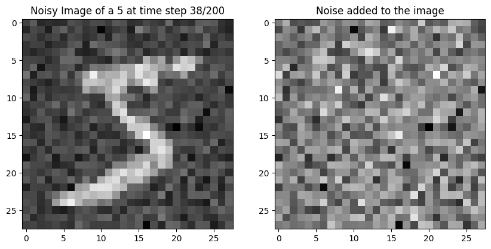

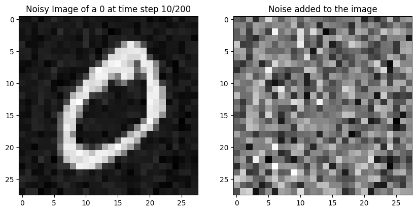

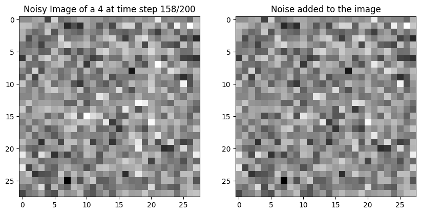

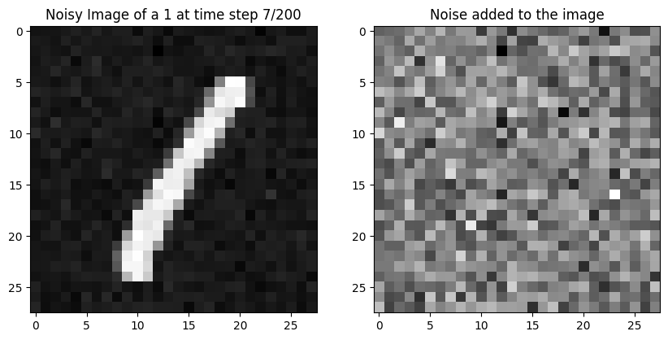

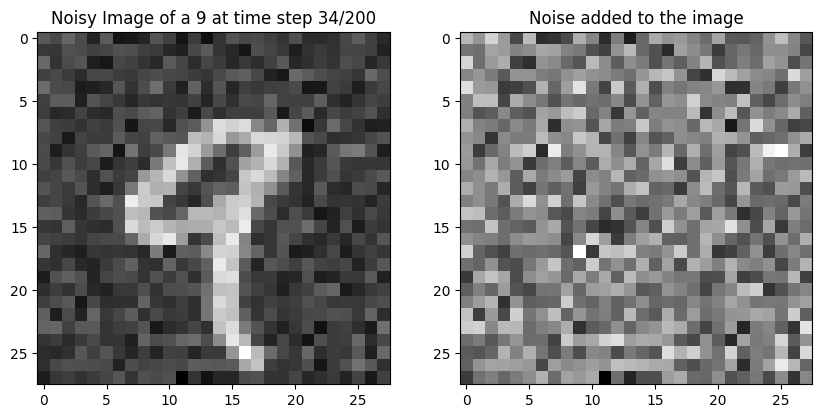

```python
class NoiseDataset():
    def __init__(self, imgs_dataset, noise_schedule = None):
        self.imgs_dataset = imgs_dataset
        self.noise_schedule = noise_schedule if noise_schedule else CosineNoiseAdder()

    def __getitem__(self, idx):
        img, label = self.imgs_dataset[idx]
        t = torch.randint(self.noise_schedule.T, (1, )).squeeze()
        noisy_img, noise = self.noise_schedule.image_at_time_step(img, t)
        return noisy_img, noise, t, label

    def __len__(self):
        return len(self.imgs_dataset)

# example of how to use the NoiseDataset class
CosineNoise = CosineNoiseAdder(T=200)
train = NoiseDataset(MNIST, CosineNoise)

for i in range(5):
    noisy_img, noise, t, label = train[i]
    fig, axs = plt.subplots(1, 2, figsize=(10, 5))
    axs[0].imshow(noisy_img[0].numpy(), cmap='gray')
    axs[0].set_title(f"Noisy Image of a {label} at time step {t}/{CosineNoise.T}")
    axs[1].imshow(noise[0].numpy(), cmap='gray')
    axs[1].set_title(f"Noise added to the image")
    plt.show()
```

The goal is to train the model to denoise the images by learning the reverse diffusion process. This consists of learning to predict the noise that was added to the image at each timestep. The model will receive the noisy image as input (left), and will try to predict the added noise (right) for this timestep.

## U-net Model

The Unet architecture is a type of convolutional neural network that is commonly used for image generation. It consists of an encoder and a decoder, with skip connections between the two. The encoder downsamples the input image, while the decoder upsamples it back to the original size. The skip connections allow the model to retain spatial information from the encoder, which helps improve the quality of the generated images.

Here is a schema of a U-net model:

[figure not shown]

### Unet Implementation Explications

This implementation has two main type of classes :

- **Architecture classes** : these classes are used to create the architecture of the model. They are used to create the encoder and decoder blocks, as well as the skip connections.
- **Embeddings classes** : these classes are used to create the embeddings for the model. They are used to create the positional embeddings and the time embeddings.

We create these classes to make the code more modular and easier to understand. Each class has a specific purpose and can be reused in different parts of the code. This also makes it easier to test and debug the code, as each class can be tested independently. The architecture classes are used to create the encoder and decoder blocks, as well as the skip connections. Here are the classes:

- **DownBlock** : This class is used to create the encoder blocks. It consists of multiple convolutional layers, followed by a Batchnorm, a SiLU activation function and some dropout. At the end, a Maxpooling is applied to downsamples the input image by a factor of 2. Before the Maxpooling, a clone of the current tensor is created to be used in the skip connection. The output of the block is a tuple containing the downsampled image and the skip connection. The down block is where the model learns to extract features from the input image. The downsampling allows the model to learn more complex features at each level of the network.

[figure not shown]

- **Bottleneck** : This class is the one at the lowest level of the U-net. It consists of multiple convolutional layers, followed a Batchnorm, a SiLU activation function and some dropout. Then a Transpose convolution is applied to upsample the image by a factor of 2. The output of the block is this upsampled image. The bottleneck, is the most important part of the model. It is where the model learns to use the deepest features of the image.

[figure not shown]

- **UpBlock** : This class is used to create the decoder blocks. First of all, it starts by concatenating the input image with the skip connection from the encoder. Then, it applies multiple convolutional layers, followed by a Batchnorm, a SiLU activation function and some dropout. Finally, a Transpose convolution is applied to upsample the image by a factor of 2. The output of the block is the upsampled image. This block is where the model learns to reconstruct the image from the features extracted by the encoder. The skip connection allows the model to retain spatial information from the encoder, which helps improve the quality of the generated images.

[figure not shown]

- **Final Block** : This class is used to create the final block of the model. It is the same as the upblock, but it does not apply the transpose convolution at the end. Instead it applies another convolutional layer. The output of the block is the final image. This block is where the model learns to generate the final image from the features extracted by the encoder.

[figure not shown]

By combining these classes, we can create the desired U-net architecture.

### Embedding Implementation Explications

There are two types of embeddings in the model :

- **Time Embedding** : This class is used to create the embeddings for the timesteps of the model. It uses a Sinusoidal Position Embedding to create the embeddings. The Sinusoidal class is used to convert the timesteps to a sinusoidal representation. This is to make the model invariant to the order of the timesteps. After the Sinusoidal representation, a linear layer followed by a SiLU activation function, and another linear layer are applied. The output of the block is the time embedding.
- **Label Embedding** : This class is used to create the embeddings for the labels of the model. It first convert the label into an embedding vector, and then project this vector by using a linear layer followed by a SiLU activation function, and another linear layer. The output of the block is the label embedding.

These two embeddings are added together to create the final embedding for the model. The final embedding is then passed to the U-net model.

### Unet main class

This implementation of the Unet architecture is highly modular and easy to manage. Below is a detailed explanation of the different parts of the architecture, separated into the main architectural components and the embedding classes.

## Unet Class

The `Unet` class represents the entire Unet architecture, combining the downsampling blocks, bottleneck, upsampling blocks, and final block.

- **Initialization Parameters:**
  - `first_hidden`: Number of channels in the first hidden layer.
  - `depth`: Depth of the Unet architecture. (Number of downsampling and upsampling blocks.)
  - `embed_dim`: Dimension of the embeddings.
  - `num_label`: Number of labels.
  - `initial_channels`: Number of initial input channels. (for example : 1 for grayscale images, 3 for RGB images...)
  - `conv_layers`: Number of convolutional layers in each block.
  - `dropout`: Dropout rate.
- **Forward Pass:**
  - Generates time embeddings and optionally label embeddings.
  - Concatenates the input with the embeddings.
  - Passes the input through the downsampling blocks, bottleneck, upsampling blocks, and final block.
  - Returns the output.

  The forward pass also has a `verbose` parameter that, when set to `True`, prints the shapes of the tensors at each stage of the forward pass. This was very useful for debugging and understanding the flow of data through the network.

[figure not shown]

```python
import torch
import torch.nn as nn


class DownBlock(nn.Module):
    def __init__(self, input_channels:int, output_channels:int, conv_layers:int=2, kernel_size:int=3, dropout:float=0.0):
        super().__init__()
        self.silu = nn.SiLU()
        self.convs = nn.ModuleList()
        self.convs.append(nn.Conv2d(input_channels, output_channels, kernel_size, padding=1))
        self.norms = nn.ModuleList([nn.BatchNorm2d(output_channels) for _ in range(conv_layers)])
        self.dropouts = nn.ModuleList([nn.Dropout(dropout) for _ in range(conv_layers)])
        for _ in range(conv_layers - 1):
            self.convs.append(nn.Conv2d(output_channels, output_channels, kernel_size, padding=1))
        self.max_pooling = nn.MaxPool2d(kernel_size=3, stride=2, padding=1)

    def forward(self, x):
        for conv, norm, dropout in zip(self.convs, self.norms, self.dropouts):
            x = dropout(self.silu(norm(conv(x))))
        x_link = x.clone()
        x = self.max_pooling(x_link)
        return x, x_link

class BottleNeck(nn.Module):
    def __init__(self, input_channels:int, hidden_channels:int, conv_layers:int=2, kernel_size:int=3, dropout:float=0.0):
        super().__init__()
        self.convs = nn.ModuleList()
        self.convs.append(nn.Conv2d(input_channels, hidden_channels, kernel_size, padding=1))
        self.norms = nn.ModuleList([nn.BatchNorm2d(hidden_channels) for _ in range(conv_layers)])
        self.dropouts = nn.ModuleList([nn.Dropout(dropout) for _ in range(conv_layers)])
        for _ in range(conv_layers - 1):
            self.convs.append(nn.Conv2d(hidden_channels, hidden_channels, kernel_size, padding=1))
        self.up_conv = nn.ConvTranspose2d(hidden_channels, hidden_channels // 2, kernel_size=2, stride=2)
        self.silu = nn.SiLU()

    def forward(self, x):
        for conv, norm, dropout in zip(self.convs, self.norms, self.dropouts):
            x = dropout(self.silu(norm(conv(x))))
        x = self.silu(self.up_conv(x))
        return x

class UpBlock(nn.Module):
    def __init__(self, input_channels:int, conv_layers:int=2, kernel_size:int=3, dropout:float=0.0):
        super().__init__()
        self.silu = nn.SiLU()
        self.convs = nn.ModuleList()
        self.convs.append(nn.Conv2d(input_channels * 2, input_channels, kernel_size, padding=1))
        self.norms = nn.ModuleList([nn.BatchNorm2d(input_channels) for _ in range(conv_layers)])
        self.dropouts = nn.ModuleList([nn.Dropout(dropout) for _ in range(conv_layers)])
        for _ in range(conv_layers - 1):
            self.convs.append(nn.Conv2d(input_channels, input_channels, kernel_size, padding=1))
        self.up_conv = nn.ConvTranspose2d(input_channels, input_channels // 2, kernel_size=2, stride=2)

    def forward(self, x:torch.Tensor, x_connection:torch.Tensor):
        x = torch.cat([x, x_connection], dim=1)
        for conv, norm, dropout in zip(self.convs, self.norms, self.dropouts):
            x = dropout(self.silu(norm(conv(x))))
        x = self.silu(self.up_conv(x))
        return x

class FinalBlock(nn.Module):
    def __init__(self, input_channels, conv_layers:int=2, output_channels:int=3, dropout:float=0.0):
        super().__init__()
        self.silu = nn.SiLU()
        self.convs = nn.ModuleList()
        self.convs.append(nn.Conv2d(input_channels * 2, input_channels, kernel_size=3, padding=1))
        self.norms = nn.ModuleList([nn.BatchNorm2d(input_channels) for _ in range(conv_layers)])
        self.dropouts = nn.ModuleList([nn.Dropout(dropout) for _ in range(conv_layers)])
        for _ in range(conv_layers - 1):
            self.convs.append(nn.Conv2d(input_channels, input_channels, kernel_size=3, padding=1))
        self.final_conv = nn.Conv2d(input_channels, output_channels, kernel_size=3, padding=1)

    def forward(self, x:torch.Tensor, x_connection:torch.Tensor):
        x = torch.cat([x, x_connection], dim=1)

        for conv, norm, dropout in zip(self.convs, self.norms, self.dropouts):
            x = dropout(self.silu(norm(conv(x))))

        x = self.final_conv(x)
        return x



class SinusoidalPositionEmbeddings(nn.Module):
    def __init__(self, dim):
        super().__init__()
        self.dim = dim

    def forward(self, time):
        device = time.device
        half_dim = self.dim // 2
        embeddings = torch.log(torch.tensor(10000.0, device=device)) / (half_dim - 1)
        embeddings = torch.exp(torch.arange(half_dim, device=device) * -embeddings)
        embeddings = time[:, None] * embeddings[None, :]
        embeddings = torch.cat((embeddings.sin(), embeddings.cos()), dim=-1)
        return embeddings

class TimeEmbedding(nn.Module):
    def __init__(self, time_embed_dim, emb_dim):
        super().__init__()
        self.time_mlp = nn.Sequential(
            SinusoidalPositionEmbeddings(time_embed_dim),
            nn.Linear(time_embed_dim, emb_dim),
            nn.SiLU(),
            nn.Linear(emb_dim, emb_dim)
        )

    def forward(self, t):
        return self.time_mlp(t)

class LabelEmbedding(nn.Module):
    def __init__(self, num_classes, emb_dim):
        super().__init__()
        self.emb = nn.Embedding(num_classes, emb_dim)
        self.proj = nn.Sequential(
            nn.Linear(emb_dim, emb_dim),
            nn.SiLU(),
            nn.Linear(emb_dim, emb_dim)
        )

    def forward(self, label):
        emb = self.emb(label)
        return self.proj(emb)


class Unet(nn.Module):
    def __init__(self, first_hidden:int = 16, depth:int = 3, embed_dim:int=8, num_label:int=0, initial_channels:int=3, conv_layers:int=2, dropout:float=0.0):
        super().__init__()
        self.time_emb = TimeEmbedding(embed_dim, embed_dim)
        self.label_emb = LabelEmbedding(num_label, embed_dim) if num_label > 0 else None
        d = depth - 1
        self.down_blocks = nn.ModuleList()
        self.up_blocks = nn.ModuleList()

        self.down_blocks.append(DownBlock(initial_channels + embed_dim, first_hidden, conv_layers=conv_layers, dropout=dropout))
        for i in range(d):
            self.down_blocks.append(DownBlock(first_hidden * 2**i, first_hidden * 2**(i+1), conv_layers=conv_layers, dropout=dropout))

        self.bottleneck = BottleNeck(first_hidden*2**d, first_hidden*2**(d+1), conv_layers=3, dropout=dropout)

        for i in range(d, 0, -1):
            self.up_blocks.append(UpBlock(first_hidden * 2**i, conv_layers=conv_layers, dropout=dropout))

        self.final = FinalBlock(first_hidden, output_channels=initial_channels, conv_layers=conv_layers, dropout=dropout)


    def forward(self, x, time, label=None, verbose:int=0):
        if verbose==1: print(f'start with shape {x.shape}')

        time_embeddings = self.time_emb(time)
        time_embeddings = time_embeddings.unsqueeze(2).unsqueeze(3)
        time_embeddings = time_embeddings.expand(x.size(0), time_embeddings.size(1), x.size(2), x.size(3))

        embeddings = time_embeddings
        if self.label_emb:
            if verbose==1: print(f'label shape : {label.shape}')
            label_embeddings = self.label_emb(label)
            if verbose==1: print(f'label_embeddings shape : {label_embeddings.shape}')
            label_embeddings = label_embeddings.unsqueeze(2).unsqueeze(2)
            if verbose==1: print(f'label_embeddings shape : {label_embeddings.shape}')
            label_embeddings = label_embeddings.expand(x.size(0), label_embeddings.size(1), x.size(2), x.size(3))
            if verbose==1: print(f'label_embeddings shape : {label_embeddings.shape}')
            embeddings = embeddings + label_embeddings

        x = torch.cat([x, embeddings], dim=1)

        if verbose==1: print(f'after concatenating the timestep (& labels) embedds : {x.shape}')

        skips = []
        for i, block in enumerate(self.down_blocks):
            if verbose==1: print(f'down block {i}, with shape {x.shape}')
            x, xi = block(x)
            skips.append(xi)

        x = self.bottleneck(x)
        if verbose==1: print(f'after bottleneck : shape = {x.shape}')



        for i, block in enumerate(self.up_blocks):
            skip = skips.pop()
            if verbose==1: print(f'up block {i}, with shape {x.shape}, and skip shape : {skip.shape}')
            x = block(x, skip)

        x = self.final(x, skips[0])
        if verbose==1: print(f'after final : shape = {x.shape}')

        return x
```

## Training Loop

### Small functions before training

Before actually starting the loop we need to define some small functions that will be used in the training loop. These functions are the evaluation function, and the initialization function:

```python
# we use torch.nograd to gain speed by avoiding computing gradients since we wont backpropagate
def eval_model(model:nn.Module, _test_loader, criterion, device):
    # this function is used to evaluate the model on the test set
    # it returns the average loss on the test set
    model.eval()
    losses = []
    with torch.no_grad():
        for i, (noisy_imgs, noises, time_steps, labels) in enumerate(_test_loader):
            noisy_imgs, noises, time_steps, labels = noisy_imgs.to(device), noises.to(device), time_steps.to(device), labels.to(device)
            outputs = model(noisy_imgs, time_steps, labels)
            loss = criterion(outputs, noises)
            losses.append(loss.item())
            # print(loss, losses)
            # print(f"Batch {i}, Loss: {loss.item()}")
    return sum(losses)/len(losses)

def init_weights(m):
    # this function is used to initialize the weights of the model
    # it uses the kaiming normal initialization for the convolutional layers and the linear layers
    if isinstance(m, nn.Conv2d) or isinstance(m, nn.ConvTranspose2d):
        nn.init.kaiming_normal_(m.weight, mode='fan_in', nonlinearity='leaky_relu')
        if m.bias is not None:
            nn.init.zeros_(m.bias)
    elif isinstance(m, nn.Linear):
        nn.init.kaiming_normal_(m.weight, mode='fan_in', nonlinearity='leaky_relu')
        if m.bias is not None:
            nn.init.zeros_(m.bias)
    elif isinstance(m, (nn.BatchNorm2d, nn.GroupNorm)):
        nn.init.ones_(m.weight)
        nn.init.zeros_(m.bias)
```

We now have all the components to train the model. We will create a training loop that will train the model on the MNIST dataset.

Let's first define all the hyperparameters.

```python
from dataclasses import dataclass

@dataclass
class CFG:
    """Configuration class for model hyperparameters."""
    # Training parameters
    n_epochs: int = 30
    lr: float = 1e-3
    final_lr: float = 1e-5
    batch_size: int = 32
    n_epochs_lr: int = 20  # epochs with learning rate reduction
    patience: int = 7000  # early stopping patience
    eval_frequency: int = 0.1  # fraction of epoch between evaluations (0.1 = 10 evals per epoch)

    # Model parameters
    first_hidden: int = 32
    depth: int = 3
    conv_layers: int = 3
    embedding_dim: int = 128
    num_labels: int = 10
    dropout: float = 0.2
    initial_channels: int = 1  # 1 for MNIST, 3 for CIFAR10

    # Dataset parameters
    max_time_steps: int = 200
    dataset_name: str = "MNIST"
    image_size: int = 32

    # Other parameters
    images_precision = torch.float32  # dtype for images

    save_path: str = "best_model.pth"
    use_compile: bool = True
```

```python
def train_model(cfg:CFG, model, train, test, device=None):
    if device is None:
        # Set the device to GPU if available, else CPU
        device = torch.device('cuda' if torch.cuda.is_available() else 'cpu')
    model.to(device)
    print(f"Using device: {device}")

    model.apply(init_weights)  # Initialize model weights

    train_loader = DataLoader(train, shuffle=True, batch_size=cfg.batch_size)
    test_loader = DataLoader(test, shuffle=False, batch_size=cfg.batch_size)

    criterion = nn.MSELoss()
    optimizer = torch.optim.AdamW(model.parameters(), lr=cfg.lr)
    scheduler = torch.optim.lr_scheduler.CosineAnnealingLR(
        optimizer, T_max=cfg.n_epochs_lr * len(train_loader), eta_min=cfg.final_lr)



    # keep track of the loss
    train_losses = []
    val_losses = []
    best_loss = np.inf
    best_loss_i = 0
    stoping = False
    eval_every = int(len(train_loader) * cfg.eval_frequency) # evaluate every n% of the training set

    # Compile the model for better performance
    if cfg.use_compile:
        torch.compile(model, mode='default', dynamic=True)

    # training loop
    for epoch in range(cfg.n_epochs):
        if stoping: # if the early stopping is triggered, we stop the training
            break
        train_loader_tqdm = tqdm(train_loader, desc=f'Epoch {epoch+1}/{cfg.n_epochs}', leave=True)
        for i, batch in enumerate(train_loader_tqdm):
            noisy_imgs, noises, time_steps, labels = batch
            noisy_imgs, noises, time_steps, labels = noisy_imgs.to(device, dtype=cfg.images_precision), noises.to(device, dtype=cfg.images_precision), time_steps.to(device, dtype=torch.int16), labels.to(device, dtype=torch.int32)
            optimizer.zero_grad()

            predicted_noise = model(noisy_imgs, time_steps, labels, verbose=False)
            loss = criterion(predicted_noise, noises)

            loss.backward()
            torch.nn.utils.clip_grad_norm_(model.parameters(), max_norm=1.0)
            optimizer.step()

            train_losses.append(loss.item())

            # evaluate the model every eval_every steps
            if i % eval_every == 0 and i > 0:

                val_loss = eval_model(model, test_loader, criterion, device)
                val_losses.append(val_loss)
                # print(f'Epoch [{epoch+1}/{n_epochs}], Step [{i}/{len(train_loader)}], Loss: {loss.item():.4f}, Val Loss: {val_loss:.4f}, lr: {scheduler.get_last_lr()[0]}')

                if val_loss < best_loss:
                    best_loss = val_loss
                    best_loss_i = epoch * len(train_loader) + i
                    torch.save(model.state_dict(), cfg.save_path)

                train_loader_tqdm.set_postfix({'Loss': loss.item(), 'Val Loss': val_loss, 'best_loss' : best_loss, 'lr': scheduler.get_last_lr()[0]})

                if epoch * len(train_loader) + i - best_loss_i > cfg.patience:
                    print("Stopping early")
                    stoping = True
                    break

            if epoch < cfg.n_epochs_lr:
                scheduler.step()

        if stoping:
            break


    # plot the losses
    plt.figure(figsize=(10, 5))
    train_losses_resized = [np.mean(train_losses[i * eval_every:(i + 1) * eval_every]) for i in range(len(val_losses))]
    plt.plot(np.arange(0, len(train_losses_resized)) * eval_every / len(train_loader), train_losses_resized, label='Training Loss (averaged)')
    plt.plot(np.arange(0, len(val_losses)) * eval_every / len(train_loader), val_losses, label='Validation Loss')
    plt.xlabel('Epoch')
    plt.ylabel('Loss')
    plt.legend()
    plt.show()
```

```
Using device: cuda
```

```
Stopping early
```

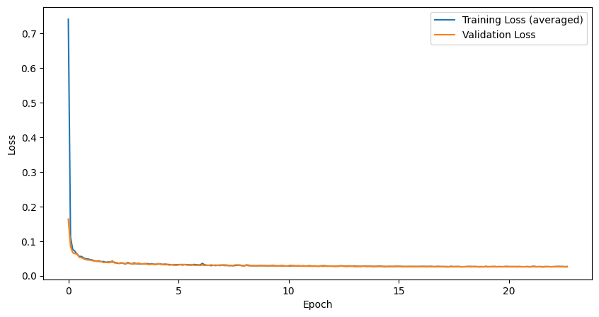

```python
config_MNIST = CFG(
    n_epochs=30,
    dataset_name='MNIST',
    image_size=32,
    use_compile=True,
    save_path = 'best_model_MNIST.pth',
    initial_channels=1
)

CosineNoise = CosineNoiseAdder(config_MNIST.max_time_steps)
trans = transforms.Compose([
    transforms.ToTensor(),
    transforms.Resize((config_MNIST.image_size, config_MNIST.image_size)),
    transforms.Normalize((0.5,), (0.5, ))
])

train = NoiseDataset(Dataset(config_MNIST.dataset_name, transform=trans), CosineNoise)
test = NoiseDataset(Dataset(config_MNIST.dataset_name, 'test', transform=trans), CosineNoise)

model = Unet(
    first_hidden=config_MNIST.first_hidden, depth=config_MNIST.depth, embed_dim=config_MNIST.embedding_dim,
    num_label=config_MNIST.num_labels, initial_channels=config_MNIST.initial_channels,
    conv_layers=config_MNIST.conv_layers, dropout=config_MNIST.dropout
)

device = torch.device('cuda' if torch.cuda.is_available() else 'cpu')
train_model(config_MNIST, model, train, test, device=device)
```

## Sample From Model

The sampling process is the reverse of the training process. It starts with a random noise image and iteratively denoises it using the trained model. The process is controlled by the noise schedule, which determines how much noise to remove at each step. The final output is a generated image that resembles the training data.

[figure not shown]

After multiple training tests, the best model we've got is this one.

```python
# model.load_state_dict(torch.load(f'../MNIST1.pth'))
model.load_state_dict(torch.load('best_model_MNIST.pth'))
model.eval()
```

[output not shown]

[output cut: 65 more lines]

[output not shown]

```python
# print(CosineNoise.get_alpha_t(T))

def sample(model, max_time_steps, n_samples=1, config=None, device=None):
    if device is None:
        device = torch.device('cuda' if torch.cuda.is_available() else 'cpu')
    CosineNoise = CosineNoiseAdder(max_time_steps, s=0.008)
    all_samples = []
    all_vis = []

    for i in range(n_samples):
        with torch.no_grad():
            full_img = torch.tensor([], device=device)
            full_predicted_noise = torch.tensor([], device=device)

            xt = torch.randn((1, config.initial_channels, 32, 32)).to(device)
            for t in torch.arange(max_time_steps-1, -1, -1):
                t = t.expand((1)).to(device)
                a_t = CosineNoise.get_alpha_t(t)
                alpha_t_barre = CosineNoise.get_alpha_t_barre(t)
                sigma = torch.sqrt(1-a_t).view(1, 1, 1, 1)
                noise = torch.randn_like(xt)
                # print(xt.shape)
                label = torch.tensor([i%10], device=device)
                epsilon = model(xt, t, label)

                # if t > 0:
                #     noise = torch.randn_like(xt)
                #     sigma_t = torch.sqrt(1 - a_t).view(1, 1, 1, 1)
                # else:
                #     noise = torch.zeros_like(xt)
                #     sigma_t = torch.zeros_like(a_t).view(1, 1, 1, 1)

                a = ((1 - a_t)/(torch.sqrt(1 - alpha_t_barre))).view(1, 1, 1, 1)
                b = (1/torch.sqrt(a_t)).view(1, 1, 1, 1)

                if t.item() % (max_time_steps / 10) == 0 or t.item() == max_time_steps-1:
                    # print(t.item())
                    full_img = torch.cat((full_img, xt), 3)
                    full_predicted_noise = torch.cat((full_predicted_noise, epsilon), 3)
                    # print(xt.shape)
                    # show_image(xt[0], f'{t.item()}%')
                    # show_image(full_img[0])

                xt = b*(xt - a*epsilon) + sigma*noise

                # xt = torch.sqrt(1 - a_t).view(1, 1, 1, 1) * noise_predicted + sigma * noise

                # xt = b * (xt - torch.sqrt(1-alpha_t_barre)*noise_predicted) + sigma*noise


            all_samples.append(xt[0].cpu())
            all_vis.append(full_img[0].cpu())

            # show_image(xt[0], title=f'Final Image of {label.item()}')
            # show_image(full_img[0])

    return all_samples, all_vis
```

[figure not shown]

[figure not shown]

[figure not shown]

[figure not shown]

[figure not shown]

[figure not shown]

[figure not shown]

[figure not shown]

[figure not shown]

[figure not shown]

```python
max_time_steps = 200
n_samples = 10

imgs, full_imgs = sample(model, max_time_steps, n_samples, config_MNIST, device=device)
for i, (xt, full_img) in enumerate(zip(imgs, full_imgs)):
    plt.figure(figsize=(10, 5))
    plt.subplot(1, 2, 1)
    plt.imshow(xt.permute(1, 2, 0).cpu().numpy(), cmap='gray')
    plt.title(f"Final Image of {i}")
    plt.subplot(1, 2, 2)
    plt.imshow(full_img.permute(1, 2, 0).cpu().numpy(), cmap='gray')
    plt.title(f"Sampling process of {i}")
    plt.show()
# show_image(xt[0], title=f"Final Image of {i}")
# show_image(full_img[0])
```

The output seems somehow correct. We can see the correct output for almost all of the images. The model is able to generate images that resemble the training data, but they are not always perfect. for example, the number 2 or the 9 does not look perfect. This is an example of a failure case. But this is also due to the randomness of the process, because by sampling multiple times from the model, we can get a perfect 2 and a very bad 5. But overall, the model is able to generate a very good amount of prefectly fine digits.

## CIFAR10 dataset

This is the beauty of this model, it is highly modular and can be easily adapted to different datasets. We just need to change the some basic parameters if needed like the input channel number or the number of labels, and the rest of the code remains the same. This is very useful for testing the model on different datasets and for comparing the results.

Here is the training on the CIFAR 10 Dataset :

```
Files already downloaded and verified
Files already downloaded and verified
Using device: cuda
```

```
Stopping early
```

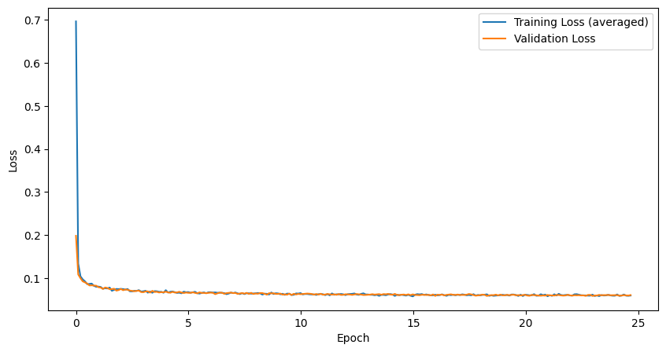

```python
config_CIFAR = CFG(
    dataset_name='CIFAR10',
    save_path = 'best_model_CIFAR.pth',
    initial_channels=3,
    image_size=32,
    n_epochs=30,

    lr=1e-3,
    final_lr=3e-5,
    n_epochs_lr=25,
    batch_size=32,
    patience=10000,

    depth=3,
    conv_layers=3,
    first_hidden=64,
    embedding_dim=64,
    max_time_steps=200,
)

CosineNoise = CosineNoiseAdder(config_CIFAR.max_time_steps)
trans = transforms.Compose([
    transforms.ToTensor(),
    transforms.Resize((config_CIFAR.image_size, config_CIFAR.image_size)),
    transforms.Normalize((0.5, 0.5, 0.5), (0.5, 0.5, 0.5))
])

train = NoiseDataset(Dataset(config_CIFAR.dataset_name, transform=trans), CosineNoise)
test = NoiseDataset(Dataset(config_CIFAR.dataset_name, 'test', transform=trans), CosineNoise)

model = Unet(
    first_hidden=config_CIFAR.first_hidden, depth=config_CIFAR.depth, embed_dim=config_CIFAR.embedding_dim,
    num_label=config_CIFAR.num_labels, initial_channels=config_CIFAR.initial_channels,
    conv_layers=config_CIFAR.conv_layers, dropout=config_CIFAR.dropout
)

device = torch.device('cuda' if torch.cuda.is_available() else 'cpu')
train_model(config_CIFAR, model, train, test, device=device)
```

```
Clipping input data to the valid range for imshow with RGB data ([0..1] for floats or [0..255] for integers).
Clipping input data to the valid range for imshow with RGB data ([0..1] for floats or [0..255] for integers).
```

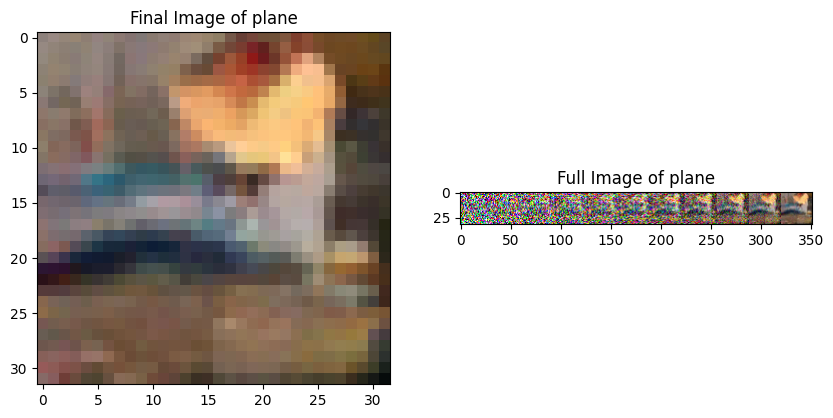

```
Clipping input data to the valid range for imshow with RGB data ([0..1] for floats or [0..255] for integers).
Clipping input data to the valid range for imshow with RGB data ([0..1] for floats or [0..255] for integers).
```

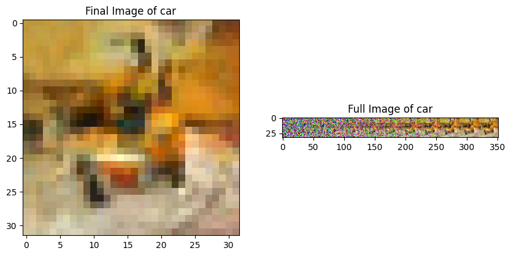

```
Clipping input data to the valid range for imshow with RGB data ([0..1] for floats or [0..255] for integers).
Clipping input data to the valid range for imshow with RGB data ([0..1] for floats or [0..255] for integers).
```

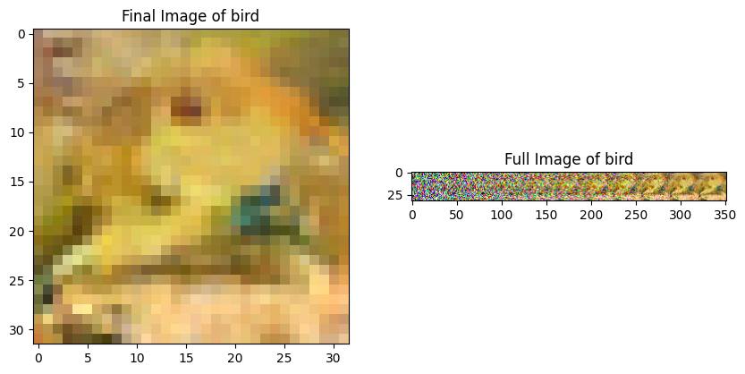

```
Clipping input data to the valid range for imshow with RGB data ([0..1] for floats or [0..255] for integers).
Clipping input data to the valid range for imshow with RGB data ([0..1] for floats or [0..255] for integers).
```

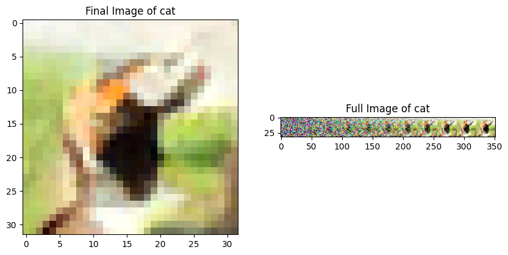

```
Clipping input data to the valid range for imshow with RGB data ([0..1] for floats or [0..255] for integers).
```

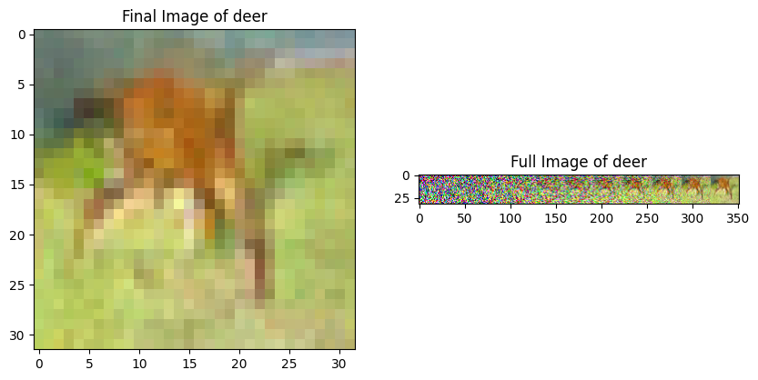

```
Clipping input data to the valid range for imshow with RGB data ([0..1] for floats or [0..255] for integers).
Clipping input data to the valid range for imshow with RGB data ([0..1] for floats or [0..255] for integers).
```

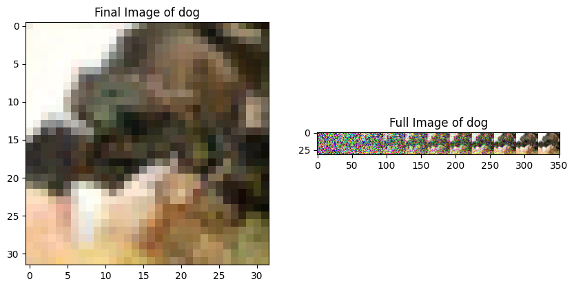

```
Clipping input data to the valid range for imshow with RGB data ([0..1] for floats or [0..255] for integers).
Clipping input data to the valid range for imshow with RGB data ([0..1] for floats or [0..255] for integers).
```

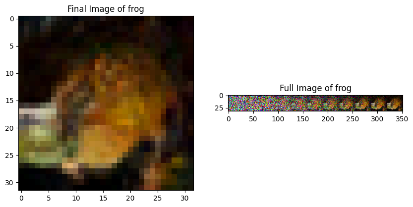

```
Clipping input data to the valid range for imshow with RGB data ([0..1] for floats or [0..255] for integers).
Clipping input data to the valid range for imshow with RGB data ([0..1] for floats or [0..255] for integers).
```

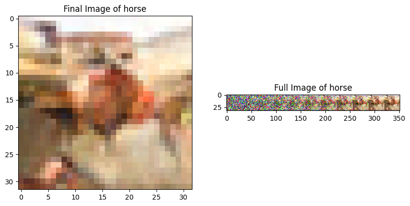

```
Clipping input data to the valid range for imshow with RGB data ([0..1] for floats or [0..255] for integers).
Clipping input data to the valid range for imshow with RGB data ([0..1] for floats or [0..255] for integers).
```

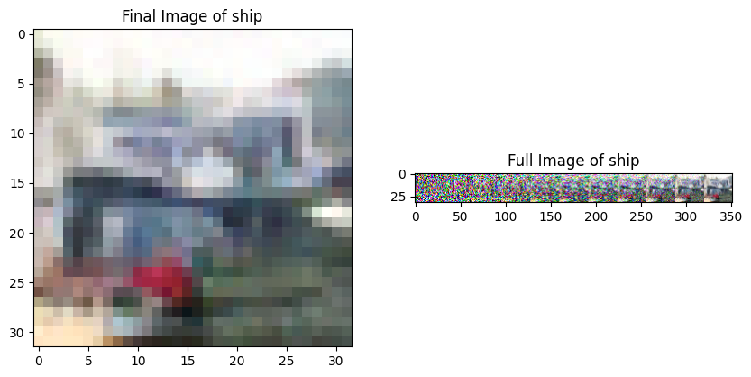

```
Clipping input data to the valid range for imshow with RGB data ([0..1] for floats or [0..255] for integers).
Clipping input data to the valid range for imshow with RGB data ([0..1] for floats or [0..255] for integers).
```

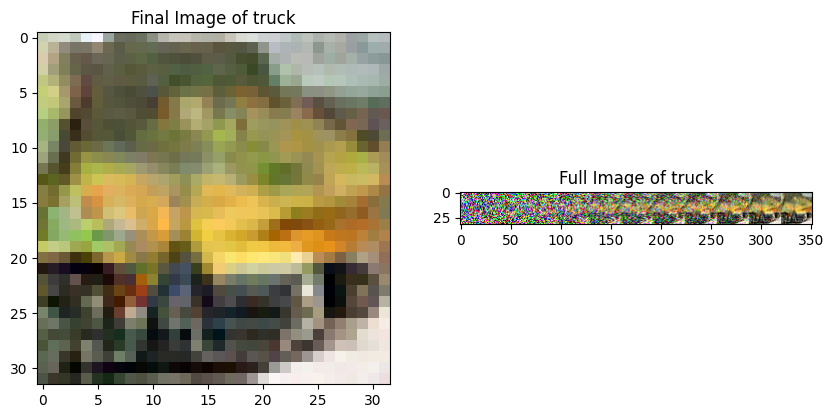

```python
model = Unet(
    first_hidden=config_CIFAR.first_hidden, depth=config_CIFAR.depth, embed_dim=config_CIFAR.embedding_dim,
    num_label=config_CIFAR.num_labels, initial_channels=config_CIFAR.initial_channels,
    conv_layers=config_CIFAR.conv_layers, dropout=config_CIFAR.dropout
).to(device)
model.load_state_dict(torch.load(config_CIFAR.save_path))
max_time_steps = 200
n_samples = 10

model.eval()

classes = ['plane', 'car', 'bird', 'cat', 'deer', 'dog', 'frog', 'horse', 'ship', 'truck']

imgs, full_imgs = sample(model, max_time_steps, n_samples, config_CIFAR)

for i, (xt, full_img) in enumerate(zip(imgs, full_imgs)):
    # show_image(xt, title=f'Final Image of {i}')
    # show_image(full_img, title=f'Sampling process of {classes[i]}')
    xt = xt / 2 + 0.5  # unnormalize
    full_img = full_img / 2 + 0.5  # unnormalize

    plt.figure(figsize=(10, 5))
    plt.subplot(1, 2, 1)
    plt.imshow(xt.permute(1, 2, 0).cpu().numpy(), cmap='gray')
    plt.title(f"Final Image of {classes[i]}")
    plt.subplot(1, 2, 2)
    plt.imshow(full_img.permute(1, 2, 0).cpu().numpy(), cmap='gray')
    plt.title(f"Full Image of {classes[i]}")
    plt.show()
```

By looking at the few samples from this model, we can see multiple things. First of all, the model is able to generate images that resemble the training data. Even if we dont always recognize what's in the image, we can see that the model generates images that almost look like something. This is also because our model generates images of shape 32x32, which is very small. So the output images are very pixelated, therefore we can not see the details of the images.

But sometimes the model generates images that look more like another class than the one we are trying to generate. This is caused by a lack of training, and a model not good enough. To improve this, we can try to train the model for a longer time, using better hyperparameters, or using a better model. We can also try to use a larger dataset, or a more complex dataset. But overall, the model is able to generate images that resemble the training data, and this is a good sign.

Another point is that the model is able to generate images that are very different from each other. This is a great, as it means that the model is able to learn the distribution of the training data and generate new images that are not just copies of the training data.

# Explanation of choices

Here are some explanations of the choices we made for the project.

- **Model** : We used a U-net architecture because it is a very powerful architecture for image generation. It is able to generate high quality images and is very flexible. It can be easily adapted to different datasets and different tasks. The U-net architecture is also very popular in the research community, so it is a good choice for this project.
- **Cosine noise schedule** : We used a cosine noise schedule because it is a very effective way to add noise to the images. It's better than the simple linear noise schedule. It allows the model to learn to denoise the images in a more efficient way.
- **Sinusoidal position embedding** : We used a sinusoidal position embedding instead of a simple linear embedding because this allows the model to use close timesteps in a similar way, and not loose that information.
- **SILU activation function** : We used the SILU activation function because it is an effective activation function for image generation. It's very close to a relu : Its formula is : $f(x) = x * sigmoid(x)$.

[figure not shown]

# Conclusion

We hope that we will be able to train this model for even longer time, and to improve the results. We arealso looking forward to apply this model to other datasets and to improve it even more. We are also looking forward to exploring other generative models and to compare the results with the DDPM model.

## References

- Denoising Diffusion Probabilistic Models - https://arxiv.org/abs/2006.11239
- Cosine Noise Schedule - https://arxiv.org/pdf/2102.09672
- pytorch documentation - https://pytorch.org/docs/stable/index.html

## Future Improvements

We can list a few improvements that can be made to the model :

- **Use a bigger model** : We can use a bigger model with more layers and more channels. This would allow the model to learn more complex features and to generate higher quality images. We can also use a bigger batch size, this would allow the model to learn from more data at once and to converge faster.
- **Train the model for more epochs** : We can train the model for more epochs. Because so far, the model does not show any sign of overfitting, which means that we can train it for more epochs without overfitting. This would allow the model to learn more complex features and to generate higher quality images.
- **Add a attention mechanism** : We can add an attention mechanism to the model. This would allow the model to focus on the important parts of the image and to generate higher quality images.
- **Add Transformer for labels** : We can add a transformer for the labels. This implies to have another dataset that suits this. This would allow the model to create images using a sentence, with a description of the image. This would create new images that does not exist in the dataset, but that somehow combines what the model saw in the dataset. This is a very interesting task and it would be a good addition to the model.
- **Implement more datasets** : We can implement more datasets. The model is very modular and can be easily adapted to different datasets. We can try to implement more datasets and see if the model performs well on them. This would allow us to test the model on different tasks and to compare the results. Because so far, the model is only trained on MNIST and CIFAR10, two datasets with very low resoltion images (28x28 and 32x32). We can try to implement more complex datasets, like CelebA or LSUN. This would allow us to test the model on more complex tasks and to compare the results with other models.
- **Use a better training process** : We can use a better training process. The training process is very important for the quality of the generated images. We can try to implement different training processes and see if they improve the results of the model. For example, we can try to use a different optimizer or different learning rate schedulers.